# Rを用いたデータ解析の 基礎とその実践

※石川由希博士（名古屋大学）が作製した資料を再構成したものです。  
※資料の一部は岩嵜航博士（東北大学）が作製したものです。  
（左右キーで進みます！）

## もう少し高度なデータ解析へ！

### 1. 課題を見つける／仮説を立てる

### 2. 実験や観察をしてデータを集める

### 3. **データを整理する**

### 4. **データを解析して仮説を検証する**

- 生データをプロットするだけではつまらない…
- データの計算や解析もプログラミングで行おう！

## データを解析しよう

### データ解析には[dplyr](https://dplyr.tidyverse.org/)と[tidyr](https://tidyr.tidyverse.org/)が便利

### **dplyrとtidyrとは**

- tidyverseパッケージ群の一つ
- シンプルな関数がたくさん
- 繋げて使う（piping）といろんな解析ができる

### **再現性が高まる！**

### **同じデータ処理の繰り返しが楽！**

### （３回同じ操作をするならプログラミングするべし！）

## dplyrの使い方の基本！

### **パイプ演算子（%>%）で指示を繋げて使う**

```r
library(tidyverse)                 #読み込み
result = diamonds %>%              #diamondsのデータから
  select(carat, cut, price) %>%    #carat, cut, priceだけ抽出して
  filter(carat > 2) %>%            #carat > 2のデータを抽出して
  group_by(cut) %>%                #cutごとにグループにして
  summarise_all(mean) %>%          #すべての平均値を計算する
  print()                          #表示してみる
```

```
## # A tibble: 5 × 3
##   cut       carat  price
##   <ord>     <dbl>  <dbl>
## 1 Fair       2.30 11972.
## 2 Good       2.14 14629.
## 3 Very Good  2.12 15133.
## 4 Premium    2.16 14992.
## 5 Ideal      2.15 15589.
```

## さっそくやってみよう！

### サンプルデータ（[penguins](https://allisonhorst.github.io/palmerpenguins/))で練習します

## dplyrを使ってみよう！

### 【復習】まずはサンプルデータ（[penguins](https://allisonhorst.github.io/palmerpenguins/))をインストール

```r
install.packages("palmerpenguins")    #インストールは最初の１回でOK
```

### 【復習】インストールしたら読み込み

```r
library(palmerpenguins)               #penguinsを読み込み
library(tidyverse)                    #tidyverseを読み込み
```

## dplyrを使ってみよう！

### 文法（１）データをざっくり眺める

```r
head(penguins)                        #penguinsの最初を見せて！
```

```
## # A tibble: 6 × 8
##   species island bill_length_mm bill_depth_mm flipper_length_… body_mass_g sex
##   <fct>   <fct>           <dbl>         <dbl>            <int>       <int> <fct>
## 1 Adelie  Torge…           39.1          18.7              181        3750 male
## 2 Adelie  Torge…           39.5          17.4              186        3800 fema…
## 3 Adelie  Torge…           40.3          18                195        3250 fema…
## 4 Adelie  Torge…           NA            NA                 NA          NA <NA>
## 5 Adelie  Torge…           36.7          19.3              193        3450 fema…
## 6 Adelie  Torge…           39.3          20.6              190        3650 male
## # … with 1 more variable: year <int>
```

## dplyrを使ってみよう！

### 文法（２）データの変数をリストアップする

- **str(【data.frameの名前】)**
- どの列を指定したらいいか調べるときに便利

```r
str(penguins)                         #penguinsデータの変数を確認
```

```
## tibble [344 × 8] (S3: tbl_df/tbl/data.frame)
##  $ species          : Factor w/ 3 levels "Adelie","Chinstrap",..: 1 1 1 1 1 1 1 1 1 1 ...
##  $ island           : Factor w/ 3 levels "Biscoe","Dream",..: 3 3 3 3 3 3 3 3 3 3 ...
##  $ bill_length_mm   : num [1:344] 39.1 39.5 40.3 NA 36.7 39.3 38.9 39.2 34.1 42 ...
##  $ bill_depth_mm    : num [1:344] 18.7 17.4 18 NA 19.3 20.6 17.8 19.6 18.1 20.2 ...
##  $ flipper_length_mm: int [1:344] 181 186 195 NA 193 190 181 195 193 190 ...
##  $ body_mass_g      : int [1:344] 3750 3800 3250 NA 3450 3650 3625 4675 3475 4250 ...
##  $ sex              : Factor w/ 2 levels "female","male": 2 1 1 NA 1 2 1 2 NA NA ...
##  $ year             : int [1:344] 2007 2007 2007 2007 2007 2007 2007 2007 2007 2007 ...
```

## dplyrを使ってみよう！

### 文法（３）指定した列を抽出する

- **select(【列名】)**
  - 指定した 列名の列を取り出す

```r
result = penguins %>%                    #penguinsのデータから
  select(species, bill_length_mm)        #species, bill_length_mm だけ抽出
head(result)                             #表示
```

```
## # A tibble: 6 × 2
##   species bill_length_mm
##   <fct>            <dbl>
## 1 Adelie            39.1
## 2 Adelie            39.5
## 3 Adelie            40.3
## 4 Adelie            NA
## 5 Adelie            36.7
## 6 Adelie            39.3
```

## dplyrを使ってみよう！

### 文法（３）指定した列を抽出する

- **select(【列番号】)**
  - 列番号でも指定できる

```r
result = penguins %>%                    #penguinsのデータから
  select(1, 4)                           #1, 4列目を抽出
head(result)                             #表示
```

```
## # A tibble: 6 × 2
##   species bill_depth_mm
##   <fct>           <dbl>
## 1 Adelie           18.7
## 2 Adelie           17.4
## 3 Adelie           18
## 4 Adelie           NA
## 5 Adelie           19.3
## 6 Adelie           20.6
```

## dplyrを使ってみよう！

### 文法（３）指定した列を抽出する

- **select(starts_with(“【文字】”))**
  - 部分一致でも指定できる
  - 文字は""で囲むこと！

```r
result = penguins %>%                    #penguinsのデータから
  select(starts_with("b"))               #bで始まる列を抽出
head(result)                             #表示
```

```
## # A tibble: 6 × 3
##   bill_length_mm bill_depth_mm body_mass_g
##            <dbl>         <dbl>       <int>
## 1           39.1          18.7        3750
## 2           39.5          17.4        3800
## 3           40.3          18          3250
## 4           NA            NA            NA
## 5           36.7          19.3        3450
## 6           39.3          20.6        3650
```

## dplyrを使ってみよう！

### 文法（３）指定した列を抽出する

- **select(-【列名】)**
  - 指定した以外（マイナス）でも抽出できる

```r
result = penguins %>%                    #penguinsのデータから
  select(-island)                        #island以外を抽出
head(result)                             #表示
```

```
## # A tibble: 6 × 7
##   species bill_length_mm bill_depth_mm flipper_length_mm body_mass_g sex    year
##   <fct>            <dbl>         <dbl>             <int>       <int> <fct> <int>
## 1 Adelie            39.1          18.7               181        3750 male   2007
## 2 Adelie            39.5          17.4               186        3800 fema…  2007
## 3 Adelie            40.3          18                 195        3250 fema…  2007
## 4 Adelie            NA            NA                  NA          NA <NA>   2007
## 5 Adelie            36.7          19.3               193        3450 fema…  2007
## 6 Adelie            39.3          20.6               190        3650 male   2007
```

## dplyrを使ってみよう！

### ［練習問題］

- islandとbody_mass_gを抽出して表示してみよう
- （次ページに答えがあります）

## dplyrを使ってみよう！

### ［練習問題］

- islandとbody_mass_gを抽出して表示してみよう

```r
result = penguins %>%                    #penguinsのデータから
  select(island, body_mass_g)            #islandとbody_mass_gを抽出
head(result)                             #表示
```

```
## # A tibble: 6 × 2
##   island    body_mass_g
##   <fct>           <int>
## 1 Torgersen        3750
## 2 Torgersen        3800
## 3 Torgersen        3250
## 4 Torgersen          NA
## 5 Torgersen        3450
## 6 Torgersen        3650
```

## dplyrを使ってみよう！

### 文法（４）特定の値の行を抽出する

- **filter(【列名】 == 【値】)**
  - 完全一致は ==
  - 文字列は""で囲む

```r
result = penguins %>%                    #penguinsのデータから
  filter(species == "Gentoo")            #ジェンツーペンギンだけを抽出
head(result)                             #表示
```

```
## # A tibble: 6 × 8
##   species island bill_length_mm bill_depth_mm flipper_length_… body_mass_g sex
##   <fct>   <fct>           <dbl>         <dbl>            <int>       <int> <fct>
## 1 Gentoo  Biscoe           46.1          13.2              211        4500 fema…
## 2 Gentoo  Biscoe           50            16.3              230        5700 male
## 3 Gentoo  Biscoe           48.7          14.1              210        4450 fema…
## 4 Gentoo  Biscoe           50            15.2              218        5700 male
## 5 Gentoo  Biscoe           47.6          14.5              215        5400 male
## 6 Gentoo  Biscoe           46.5          13.5              210        4550 fema…
## # … with 1 more variable: year <int>
```

## dplyrを使ってみよう！

### 文法（４）特定の値の行を抽出する

- **filter(【列名】 %in% c(【値1】, 【値2】))**
  - 複数の値も抽出できる
  - 複数の値はベクトルc(A, B, C)で与える

```r
result = penguins %>%                            #penguinsのデータから
  filter(species %in% c("Chinstrap", "Gentoo"))  #ヒゲとジェンツーだけを抽出
head(result)                                     #表示
```

```
## # A tibble: 6 × 8
##   species island bill_length_mm bill_depth_mm flipper_length_… body_mass_g sex
##   <fct>   <fct>           <dbl>         <dbl>            <int>       <int> <fct>
## 1 Gentoo  Biscoe           46.1          13.2              211        4500 fema…
## 2 Gentoo  Biscoe           50            16.3              230        5700 male
## 3 Gentoo  Biscoe           48.7          14.1              210        4450 fema…
## 4 Gentoo  Biscoe           50            15.2              218        5700 male
## 5 Gentoo  Biscoe           47.6          14.5              215        5400 male
## 6 Gentoo  Biscoe           46.5          13.5              210        4550 fema…
## # … with 1 more variable: year <int>
```

## dplyrを使ってみよう！

### 文法（４）特定の値の行を抽出する

- **filter(【列名】 > 【値】)**
  - 比較演算子も使える

```r
result = penguins %>%                #penguinsのデータから
  filter(bill_length_mm < 45)        #bill_length_mmが45以下を抽出
head(result)                         #表示
```

```
## # A tibble: 6 × 8
##   species island bill_length_mm bill_depth_mm flipper_length_… body_mass_g sex
##   <fct>   <fct>           <dbl>         <dbl>            <int>       <int> <fct>
## 1 Adelie  Torge…           39.1          18.7              181        3750 male
## 2 Adelie  Torge…           39.5          17.4              186        3800 fema…
## 3 Adelie  Torge…           40.3          18                195        3250 fema…
## 4 Adelie  Torge…           36.7          19.3              193        3450 fema…
## 5 Adelie  Torge…           39.3          20.6              190        3650 male
## 6 Adelie  Torge…           38.9          17.8              181        3625 fema…
## # … with 1 more variable: year <int>
```

## うまく抽出できたかな…？

### 【復習】試しにプロットしてみよう！

### まずは**何もしていないデータ（penguins）**で！

- data.frame…penguins
- X軸…bill_length_mm
- Y軸…bill_depth_mm
- 色…species
- （次ページに答えがあります）

## うまく抽出できたかな…？

### 【復習】試しにプロットしてみよう！

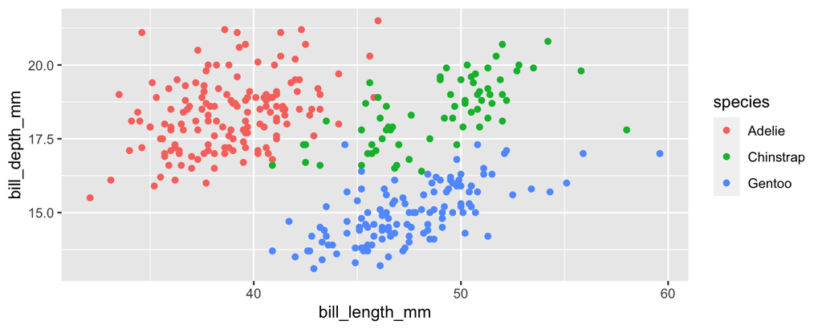

```r
gp = ggplot(data = penguins) +
     geom_point(aes(x = bill_length_mm, y = bill_depth_mm, color = species))
gp
```

## うまく抽出できたかな…？

### 【復習】試しにプロットしてみよう！

### 今度は**抽出したデータ（result）**で！

- data.frame…result
- X軸…bill_length_mm
- Y軸…bill_depth_mm
- 色…species
- （次ページに答えがあります）

## うまく抽出できたかな…？

### 【復習】試しにプロットしてみよう！

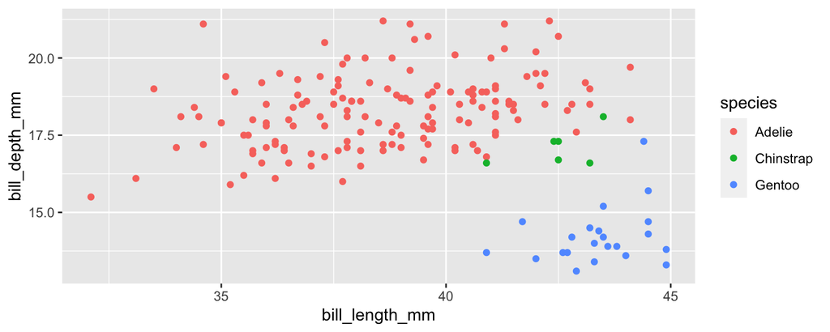

```r
gp = ggplot(data = result) +
     geom_point(aes(x = bill_length_mm, y = bill_depth_mm, color = species))
gp
```

- 45以下のデータだけになってますね！

## dplyrを使ってみよう！

### 文法（４）特定の値の行を抽出する

- **filter(【列名A】 > 【値】, 【列名B】 > 【値】)**
  - AND(,)も使える

```r
result = penguins %>%
  filter(bill_length_mm < 45, bill_depth_mm > 16)
head(result)
```

```
## # A tibble: 6 × 8
##   species island bill_length_mm bill_depth_mm flipper_length_… body_mass_g sex
##   <fct>   <fct>           <dbl>         <dbl>            <int>       <int> <fct>
## 1 Adelie  Torge…           39.1          18.7              181        3750 male
## 2 Adelie  Torge…           39.5          17.4              186        3800 fema…
## 3 Adelie  Torge…           40.3          18                195        3250 fema…
## 4 Adelie  Torge…           36.7          19.3              193        3450 fema…
## 5 Adelie  Torge…           39.3          20.6              190        3650 male
## 6 Adelie  Torge…           38.9          17.8              181        3625 fema…
## # … with 1 more variable: year <int>
```

## うまく抽出できたかな…？

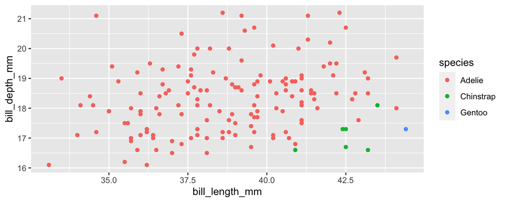

```r
gp = ggplot(data = result) +
     geom_point(aes(x = bill_length_mm, y = bill_depth_mm, color = species))
gp
```

## dplyrを使ってみよう！

### 文法（４）特定の値の行を抽出する

- **filter(【列名A】 > 【値】|【列名B】 > 【値】)**
  - OR(|)も使える

```r
result = penguins %>%
  filter(bill_length_mm < 40| bill_length_mm > 50)
head(result)
```

```
## # A tibble: 6 × 8
##   species island bill_length_mm bill_depth_mm flipper_length_… body_mass_g sex
##   <fct>   <fct>           <dbl>         <dbl>            <int>       <int> <fct>
## 1 Adelie  Torge…           39.1          18.7              181        3750 male
## 2 Adelie  Torge…           39.5          17.4              186        3800 fema…
## 3 Adelie  Torge…           36.7          19.3              193        3450 fema…
## 4 Adelie  Torge…           39.3          20.6              190        3650 male
## 5 Adelie  Torge…           38.9          17.8              181        3625 fema…
## 6 Adelie  Torge…           39.2          19.6              195        4675 male
## # … with 1 more variable: year <int>
```

## うまく抽出できたかな…？

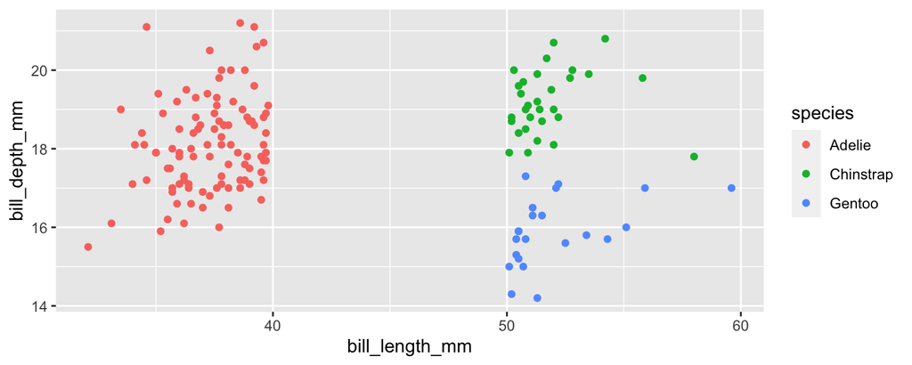

```r
gp = ggplot(data = result) +
     geom_point(aes(x = bill_length_mm, y = bill_depth_mm, color = species))
gp
```

## dplyrを使ってみよう！

### ［練習問題］

- 2008年以降のDream島のメスの体重を種ごとに比較しよう
  - どの列のどの値を取り出したらいいか？
  - 何をX軸、Y軸にして可視化したらいいか？

## dplyrを使ってみよう！

### ［練習問題］

- 2008年以降のDream島のメスの体重を種ごとに比較しよう
- データ抽出は…
  - year > 2007
  - island == “Dream”
  - sex == “female”
- データ可視化は…
  - X軸 = species
  - Y軸 = body_mass_g

## dplyrを使ってみよう！

### ［練習問題］

```r
result2 = penguins %>%
  filter(year > 2007, island == "Dream", sex == "female")
head(result2)
```

```
## # A tibble: 6 × 8
##   species island bill_length_mm bill_depth_mm flipper_length_… body_mass_g sex
##   <fct>   <fct>           <dbl>         <dbl>            <int>       <int> <fct>
## 1 Adelie  Dream            37.3          17.8              191        3350 fema…
## 2 Adelie  Dream            36.9          18.6              189        3500 fema…
## 3 Adelie  Dream            38.9          18.8              190        3600 fema…
## 4 Adelie  Dream            35.7          18                202        3550 fema…
## 5 Adelie  Dream            34            17.1              185        3400 fema…
## 6 Adelie  Dream            36.2          17.3              187        3300 fema…
## # … with 1 more variable: year <int>
```

## dplyrを使ってみよう！

### ［練習問題］

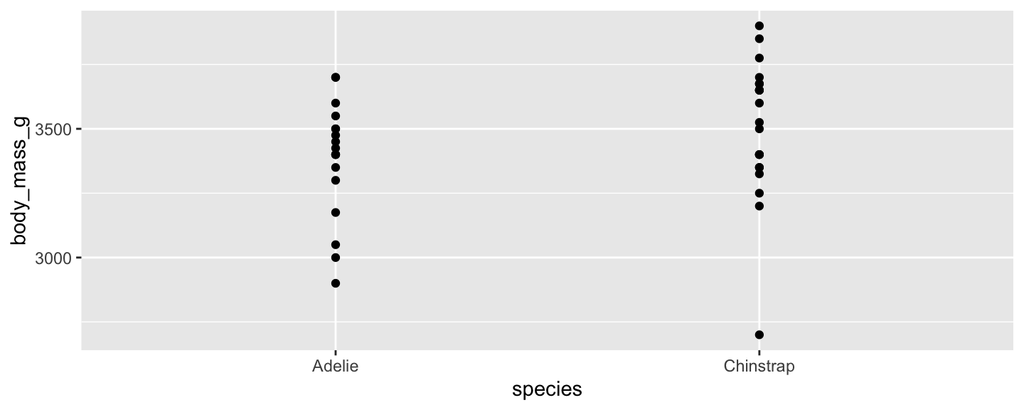

```r
gp = ggplot(data = result2) +
     geom_point(aes(x = species, y = body_mass_g))
gp
```

- できた人は、種ごとに色を付けてみよう！

## dplyrを使ってみよう！

### ［練習問題］

- 2008年以降のDream島のメスの体重を種ごとに比較しよう

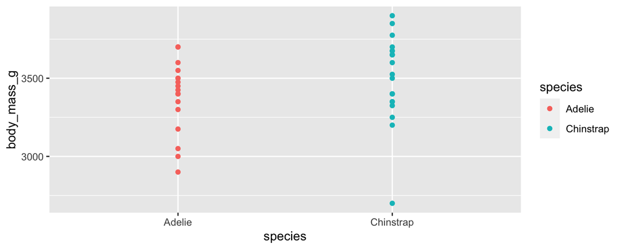

```r
gp = ggplot(data = result2) +
     geom_point(aes(x = species, y = body_mass_g, color = species))
gp
```

## dplyrを使ってみよう！

### ［練習問題］

- 2008年以降のDream島のメスの体重を種ごとに比較しよう

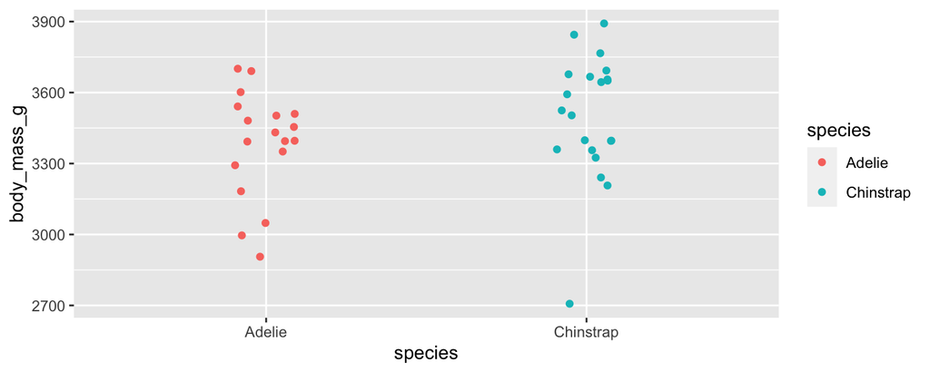

```r
gp = ggplot(data = result2) +
     geom_point(aes(x = species, y = body_mass_g, color = species),
                position = position_jitter(width = 0.1))  #横にばらつかせる
gp
```

## dplyrを使ってみよう！

### 文法（５）新しい列を作る／既存の列の値を変更する

- **mutate(【値】)**

[figure not shown]

```r
result = penguins %>%
  mutate(bill_length_mm/bill_depth_mm)  #(bill_length_mm)÷(bill_depth_mm)
head(result)
```

```
## # A tibble: 6 × 9
##   species island bill_length_mm bill_depth_mm flipper_length_… body_mass_g sex
##   <fct>   <fct>           <dbl>         <dbl>            <int>       <int> <fct>
## 1 Adelie  Torge…           39.1          18.7              181        3750 male
## 2 Adelie  Torge…           39.5          17.4              186        3800 fema…
## 3 Adelie  Torge…           40.3          18                195        3250 fema…
## 4 Adelie  Torge…           NA            NA                 NA          NA <NA>
## 5 Adelie  Torge…           36.7          19.3              193        3450 fema…
## 6 Adelie  Torge…           39.3          20.6              190        3650 male
## # … with 2 more variables: year <int>, bill_length_mm/bill_depth_mm <dbl>
```

## dplyrを使ってみよう！

### 文法（５）新しい列を作る／既存の列の値を変更する

- **mutate(【値】)**

```r
result = penguins %>%
  mutate(bill_length_mm/bill_depth_mm)  #(bill_length_mm)÷(bill_depth_mm)
head(result)
```

```
## # A tibble: 6 × 9
##   species island bill_length_mm bill_depth_mm flipper_length_… body_mass_g sex
##   <fct>   <fct>           <dbl>         <dbl>            <int>       <int> <fct>
## 1 Adelie  Torge…           39.1          18.7              181        3750 male
## 2 Adelie  Torge…           39.5          17.4              186        3800 fema…
## 3 Adelie  Torge…           40.3          18                195        3250 fema…
## 4 Adelie  Torge…           NA            NA                 NA          NA <NA>
## 5 Adelie  Torge…           36.7          19.3              193        3450 fema…
## 6 Adelie  Torge…           39.3          20.6              190        3650 male
## # … with 2 more variables: year <int>, bill_length_mm/bill_depth_mm <dbl>
```

## dplyrを使ってみよう！

### 文法（５）新しい列を作る／既存の列の値を変更する

- **mutate(【列名】=【値】)**
  - 列名も指定できる
  - 条件に応じた値も入れられる
    - [mutate(if_else())とかmutate(case_when)とか](https://r-online-course.netlify.app/courses/r-introduction/s5-11/)

```r
result = penguins %>%
  mutate(slenderness = bill_length_mm/bill_depth_mm)  #slendernessと名付ける
head(result)
```

```
## # A tibble: 6 × 9
##   species island bill_length_mm bill_depth_mm flipper_length_… body_mass_g sex
##   <fct>   <fct>           <dbl>         <dbl>            <int>       <int> <fct>
## 1 Adelie  Torge…           39.1          18.7              181        3750 male
## 2 Adelie  Torge…           39.5          17.4              186        3800 fema…
## 3 Adelie  Torge…           40.3          18                195        3250 fema…
## 4 Adelie  Torge…           NA            NA                 NA          NA <NA>
## 5 Adelie  Torge…           36.7          19.3              193        3450 fema…
## 6 Adelie  Torge…           39.3          20.6              190        3650 male
## # … with 2 more variables: year <int>, slenderness <dbl>
```

## dplyrを使ってみよう！

### ［練習問題］

- flipper_length_mm/body_mass_gを計算し、ratioという新しい列として加えよう
- （次ページに答えがあります）

## dplyrを使ってみよう！

### ［練習問題］

- flipper_length_mm/body_mass_gを計算し、ratioという新しい列として加えよう

```r
result = penguins %>%
  mutate(ratio = flipper_length_mm/body_mass_g)         #ratioと名付ける
head(result)
```

```
## # A tibble: 6 × 9
##   species island bill_length_mm bill_depth_mm flipper_length_… body_mass_g sex
##   <fct>   <fct>           <dbl>         <dbl>            <int>       <int> <fct>
## 1 Adelie  Torge…           39.1          18.7              181        3750 male
## 2 Adelie  Torge…           39.5          17.4              186        3800 fema…
## 3 Adelie  Torge…           40.3          18                195        3250 fema…
## 4 Adelie  Torge…           NA            NA                 NA          NA <NA>
## 5 Adelie  Torge…           36.7          19.3              193        3450 fema…
## 6 Adelie  Torge…           39.3          20.6              190        3650 male
## # … with 2 more variables: year <int>, ratio <dbl>
```

## dplyrを使ってみよう！

### 文法（６）数値を要約する

- **summarize(【関数名】(【列名】))**
  - 使える関数はmean, median, sd, max, min, n, Q1, Q2…

```r
result = penguins %>%
  summarize(mean(bill_length_mm))       #くちばしの長さを平均する
head(result)
```

```
## # A tibble: 1 × 1
##   `mean(bill_length_mm)`
##                    <dbl>
## 1                     NA
```

- 値にNAが含まれているとNAを返す

## dplyrを使ってみよう！

### 文法（６）数値を要約する

- **summarize(【関数名】(【列名】))**
  - na.rm = TRUEとするとNAを除外して計算してくれる

```r
result = penguins %>%
  summarize(bill_length_mean = mean(bill_length_mm, na.rm = TRUE))
                                                #くちばしの長さを平均する
head(result)
```

```
## # A tibble: 1 × 1
##   bill_length_mean
##              <dbl>
## 1             43.9
```

## dplyrを使ってみよう！

### 文法（６）数値を要約する

- **summarize(【関数名】(【列名】))**
  - group_byを組み合わせるとすごく便利！

```r
result = penguins %>%
  group_by(species) %>%                  #speciesごとにグループ分けして
  summarize(bill_length_mean = mean(bill_length_mm, na.rm = TRUE),
            .groups     = "drop")        #グループわけ解除
head(result)
```

```
## # A tibble: 3 × 2
##   species   bill_length_mean
##   <fct>                <dbl>
## 1 Adelie                38.8
## 2 Chinstrap             48.8
## 3 Gentoo                47.5
```

## dplyrを使ってみよう！

### 文法（６）数値を要約する

- **summarize(【関数名】(【列名】))**
  - 複数の集計もできる！

```r
result = penguins %>%
  group_by(species) %>%                  #speciesごとにグループ分けして
  summarize(bill_length_mean = mean(bill_length_mm, na.rm = TRUE),
            bill_depth_median = median(bill_depth_mm, na.rm = TRUE), #中央値
            .groups     = "drop")
head(result)
```

```
## # A tibble: 3 × 3
##   species   bill_length_mean bill_depth_median
##   <fct>                <dbl>             <dbl>
## 1 Adelie                38.8              18.4
## 2 Chinstrap             48.8              18.4
## 3 Gentoo                47.5              15
```

## dplyrを使ってみよう！

### 文法（６）数値を要約する

- **summarize(【関数名】(【列名】))**
  - 複数のグループもできる！

```r
result = penguins %>%
  group_by(species, island) %>%     #species, islandごとにグループ分けして
  summarize(bill_length_mean = mean(bill_length_mm, na.rm = TRUE),
            bill_depth_median = median(bill_depth_mm, na.rm = TRUE), #中央値
            .groups     = "drop")
head(result)
```

```
## # A tibble: 5 × 4
##   species   island    bill_length_mean bill_depth_median
##   <fct>     <fct>                <dbl>             <dbl>
## 1 Adelie    Biscoe                39.0              18.5
## 2 Adelie    Dream                 38.5              18.4
## 3 Adelie    Torgersen             39.0              18.4
## 4 Chinstrap Dream                 48.8              18.4
## 5 Gentoo    Biscoe                47.5              15
```

## dplyrを使ってみよう！

### 文法（６）数値を要約する

- **summarize(across(【列名のベクトル】, 【関数名】))**
  - across()を使うと短く書ける

```r
result = penguins %>%
  group_by(species, island) %>%     #species, islandごとにグループ分けして
  summarize(across(c(bill_length_mm, bill_depth_mm),  mean, na.rm = TRUE),
            .groups     = "drop")
head(result)
```

```
## # A tibble: 5 × 4
##   species   island    bill_length_mm bill_depth_mm
##   <fct>     <fct>              <dbl>         <dbl>
## 1 Adelie    Biscoe              39.0          18.4
## 2 Adelie    Dream               38.5          18.3
## 3 Adelie    Torgersen           39.0          18.4
## 4 Chinstrap Dream               48.8          18.4
## 5 Gentoo    Biscoe              47.5          15.0
```

## dplyrを使ってみよう！

### ［練習問題］

- 種×性ごとのペンギンの体重の平均（mean）と分散（sd）を計算しよう
- (次ページに答えがあります)

## dplyrを使ってみよう！

### ［練習問題］

- 種×性ごとのペンギンの体重の平均（mean）と分散（sd）を計算しよう

```r
result2 = penguins %>%
  group_by(species, sex) %>%     #species, sexごとにグループ分けして
  summarize(body_mass_mean = mean(body_mass_g, na.rm = TRUE), #mean
            body_mass_sd = sd(body_mass_g, na.rm = TRUE),     #sd
            .groups     = "drop")
head(result2)
```

```
## # A tibble: 6 × 4
##   species   sex    body_mass_mean body_mass_sd
##   <fct>     <fct>           <dbl>        <dbl>
## 1 Adelie    female          3369.         269.
## 2 Adelie    male            4043.         347.
## 3 Adelie    <NA>            3540          477.
## 4 Chinstrap female          3527.         285.
## 5 Chinstrap male            3939.         362.
## 6 Gentoo    female          4680.         282.
```

## dplyrを使ってみよう！

### ［練習問題］

- 種ごとの体重の性差を棒グラフ±エラーバーで示そう
  - [棒グラフ](https://ggplot2.tidyverse.org/reference/geom_bar.html)…geom_col(x, y)
  - [エラーバー](https://ggplot2.tidyverse.org/reference/geom_linerange.html)…geom_errorbar(x, ymin, ymax)
    - ymin…【平均の列名】-【分散の列名】
    - ymax…【平均の列名】+【分散の列名】
    - width…0.2
  - 種ごとにfacet_wrap()かfacet_grid()でグラフを分ける
    - Step 2の p.25-26あたり

## dplyrを使ってみよう！

### ［練習問題］

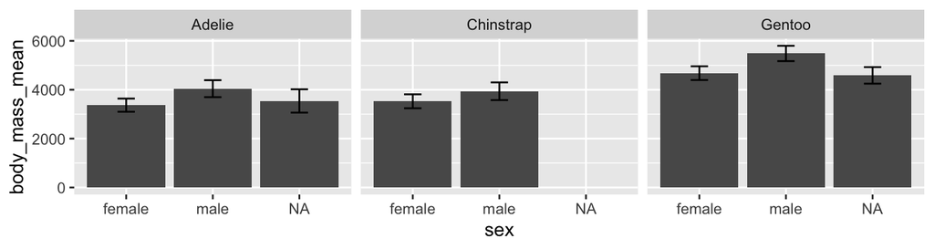

```r
gp = ggplot(data = result2) +
     geom_col(aes(x = sex, y = body_mass_mean)) +
     geom_errorbar(aes(x = sex,
                       ymin = body_mass_mean - body_mass_sd,
                       ymax = body_mass_mean + body_mass_sd),
                       width = 0.2) +
     facet_wrap(~species)
gp
```

## dplyrを使ってみよう！

### 文法（７）複数のデータフレームを結合する

### ［練習問題］ 準備として…

- penguinsのspecies, bill_length_mmをデータフレームpenguins_1に格納
- island, body_mass_gをデータフレームpenguins_2に格納
- ちゃんとできているかhead()で確認

## dplyrを使ってみよう！

### 文法（７）複数のデータフレームを結合する

### ［練習問題］ 準備として…

```r
penguins_1 = penguins %>%
  select(species, bill_length_mm)
head(penguins_1)
```

```
## # A tibble: 6 × 2
##   species bill_length_mm
##   <fct>            <dbl>
## 1 Adelie            39.1
## 2 Adelie            39.5
## 3 Adelie            40.3
## 4 Adelie            NA
## 5 Adelie            36.7
## 6 Adelie            39.3
```

## dplyrを使ってみよう！

### 文法（７）複数のデータフレームを結合する

### ［練習問題］ 準備として…

```r
penguins_2 = penguins %>%
  select(island, body_mass_g)
head(penguins_2)
```

```
## # A tibble: 6 × 2
##   island    body_mass_g
##   <fct>           <int>
## 1 Torgersen        3750
## 2 Torgersen        3800
## 3 Torgersen        3250
## 4 Torgersen          NA
## 5 Torgersen        3450
## 6 Torgersen        3650
```

## dplyrを使ってみよう！

### 文法（７）複数のデータフレームを結合する

- **bind_cols(【データフレーム１】, 【データフレーム２】)**
- **bind_rows(【データフレーム１】, 【データフレーム２】)**
  - 横につなげるならbind_cols
  - 縦につなげるならbind_rows

```r
penguins_merge = bind_cols(penguins_1, penguins_2)
head(penguins_merge)
```

```
## # A tibble: 6 × 4
##   species bill_length_mm island    body_mass_g
##   <fct>            <dbl> <fct>           <int>
## 1 Adelie            39.1 Torgersen        3750
## 2 Adelie            39.5 Torgersen        3800
## 3 Adelie            40.3 Torgersen        3250
## 4 Adelie            NA   Torgersen          NA
## 5 Adelie            36.7 Torgersen        3450
## 6 Adelie            39.3 Torgersen        3650
```

## いよいよ難関の…tidyrを使ってみよう！

### データの変形ができる最強ツール

- 他人のデータの多くは そのまま使えない…
- 手でコピペして新たなcsvを作るのはナンセンス
- そんなときは[tidyr](https://tidyr.tidyverse.org/)で一気に変換！
- ちょっとハードルは高いけど、使えるようになると 最強です

## いよいよ難関の…tidyrを使ってみよう！

### tidyrでできること

- 縦長←→横広の変換

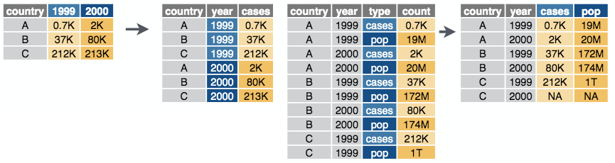

- セルの分割/結合

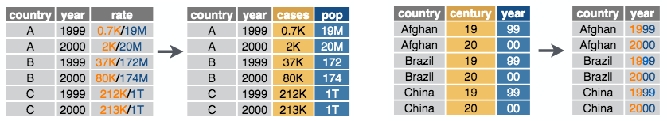

- などなど…

## tidyrを使ってみよう！

### 文法（８）縦長のデータを横広に

- **pivot_wider(names_from = 【新しく列名になる列の名前】, values_from = 【動かしたい値の列の名前】)**

```r
penguins_wide = penguins %>%
  pivot_wider(names_from = year,         #yearの列を横に並べて列名に
              values_from = body_mass_g) #値にはbody_mass_g列の値が入る
head(penguins_wide)
```

```
## # A tibble: 6 × 9
##   species island    bill_length_mm bill_depth_mm flipper_length_mm sex    `2007`
##   <fct>   <fct>              <dbl>         <dbl>             <int> <fct>   <int>
## 1 Adelie  Torgersen           39.1          18.7               181 male     3750
## 2 Adelie  Torgersen           39.5          17.4               186 female   3800
## 3 Adelie  Torgersen           40.3          18                 195 female   3250
## 4 Adelie  Torgersen           NA            NA                  NA <NA>       NA
## 5 Adelie  Torgersen           36.7          19.3               193 female   3450
## 6 Adelie  Torgersen           39.3          20.6               190 male     3650
## # … with 2 more variables: 2008 <int>, 2009 <int>
```

- 詳しい使い方は[こちら](https://heavywatal.github.io/rstats/tidyr.html)を参照

## tidyrを使ってみよう！

### 文法（８）横広のデータを縦長に

- **pivot_longer(cols = 【動かしたい値が含まれている列】, names_to = 【元々列名だったものを入れる列の名前】, values_to = 【値の移動先の列名】)**

```r
penguins_long = penguins_wide %>%
  pivot_longer(cols = c(`2007`, `2008`, `2009`), #これらを縦に並べて値に
               names_to = "YEAR",                #新たな列名はYEAR（文字列なので""で囲む）
               values_to = "BODY_MASS_G")        #元々の値を入れる列名はBODY_MASS_Gに
head(penguins_long)
```

```
## # A tibble: 6 × 8
##   species island    bill_length_mm bill_depth_mm flipper_length_mm sex    YEAR
##   <fct>   <fct>              <dbl>         <dbl>             <int> <fct>  <chr>
## 1 Adelie  Torgersen           39.1          18.7               181 male   2007
## 2 Adelie  Torgersen           39.1          18.7               181 male   2008
## 3 Adelie  Torgersen           39.1          18.7               181 male   2009
## 4 Adelie  Torgersen           39.5          17.4               186 female 2007
## 5 Adelie  Torgersen           39.5          17.4               186 female 2008
## 6 Adelie  Torgersen           39.5          17.4               186 female 2009
## # … with 1 more variable: BODY_MASS_G <int>
```

- 詳しい使い方は[こちら](https://heavywatal.github.io/rstats/tidyr.html)を参照

## tidyrを使ってみよう！

### ［練習問題］

- くちばしの長さと幅を比較するグラフを書きたいとき…
  - 比較する値はX軸に示したい

[figure not shown]

## tidyrを使ってみよう！

### ［練習問題］

- くちばしの長さと幅を比較するグラフを書きたいとき…
  - まずは元データがどうだったか確認する
  - くちばしの長さと幅を直接X軸に指定できない…

```r
head(penguins)                        #penguinsデータを確認
```

```
## # A tibble: 6 × 8
##   species island bill_length_mm bill_depth_mm flipper_length_… body_mass_g sex
##   <fct>   <fct>           <dbl>         <dbl>            <int>       <int> <fct>
## 1 Adelie  Torge…           39.1          18.7              181        3750 male
## 2 Adelie  Torge…           39.5          17.4              186        3800 fema…
## 3 Adelie  Torge…           40.3          18                195        3250 fema…
## 4 Adelie  Torge…           NA            NA                 NA          NA <NA>
## 5 Adelie  Torge…           36.7          19.3              193        3450 fema…
## 6 Adelie  Torge…           39.3          20.6              190        3650 male
## # … with 1 more variable: year <int>
```

## tidyrを使ってみよう！

### ［練習問題］

- くちばしの長さと幅を比較するグラフを書きたいとき…
  - こんな形だったら、x = PARTS, y = VALUE で指定できる

```
## # A tibble: 688 × 3
##    species PARTS          VALUE
##    <fct>   <chr>          <dbl>
##  1 Adelie  bill_length_mm  39.1
##  2 Adelie  bill_depth_mm   18.7
##  3 Adelie  bill_length_mm  39.5
##  4 Adelie  bill_depth_mm   17.4
##  5 Adelie  bill_length_mm  40.3
##  6 Adelie  bill_depth_mm   18
##  7 Adelie  bill_length_mm  NA
##  8 Adelie  bill_depth_mm   NA
##  9 Adelie  bill_length_mm  36.7
## 10 Adelie  bill_depth_mm   19.3
## # … with 678 more rows
```

## tidyrを使ってみよう！

### ［練習問題］

- くちばしの長さと幅を比較するグラフを書きたいとき…
  - pivod_longerでpenguinsを変換しよう！
  - **pivot_longer(cols = 【動かしたい値が含まれている列】, names_to = 【元々列名だったものを入れる列の名前】, values_to = 【値の移動先の列名】)**
    - もともとの列名を入れる列の名前…“PARTS”
    - 値の移動先の列名…“VALUE”
    - 動かしたい列はどれ？
      - 複数はベクトルc(【列名１】, 【列名２】)で指定

## tidyrを使ってみよう！

### ［練習問題］

```r
penguins2 = penguins %>%                                  #penguins2に格納
  pivot_longer(cols = c(bill_length_mm, bill_depth_mm),   #列を指定
               names_to = "PARTS", values_to = "VALUE")   #新たな列の名前
head(penguins2)
```

```
## # A tibble: 6 × 8
##   species island    flipper_length_mm body_mass_g sex     year PARTS       VALUE
##   <fct>   <fct>                 <int>       <int> <fct>  <int> <chr>       <dbl>
## 1 Adelie  Torgersen               181        3750 male    2007 bill_lengt…  39.1
## 2 Adelie  Torgersen               181        3750 male    2007 bill_depth…  18.7
## 3 Adelie  Torgersen               186        3800 female  2007 bill_lengt…  39.5
## 4 Adelie  Torgersen               186        3800 female  2007 bill_depth…  17.4
## 5 Adelie  Torgersen               195        3250 female  2007 bill_lengt…  40.3
## 6 Adelie  Torgersen               195        3250 female  2007 bill_depth…  18
```

- できたらggplot2でグラフを作ろう！（geom_pointで）

## tidyrを使ってみよう！

### ［練習問題］

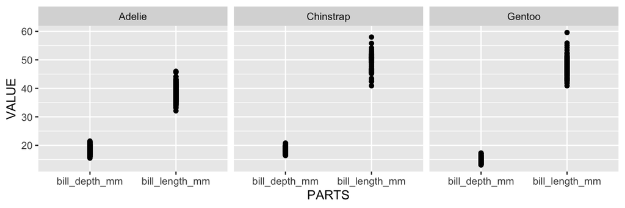

```r
gp = ggplot(data = penguins2) +
  geom_point(aes(x = PARTS, y = VALUE)) +
  facet_wrap(~species)
gp
```

## tidyrを使ってみよう！

### 文法（９）文字列カラムを複数に分割

- **separate(col = 【切り分けたい列の名前】, into = 【新しい列名】, sep = 【セパレータ】)**
  - セパレータを指定しないと非アルファベットで切れる
  - 整数を渡すと位置で切れる（“A4”を1Lで切ると“A”と“4”に）
  - 詳しい使い方は[こちら](https://heavywatal.github.io/rstats/tidyr.html)を参照

```r
penguins2_sep = penguins2 %>%
  separate(col = PARTS, into = c("A", "B", "C"), sep = "_")
　　　　　　　　　　　　　　　　　　　　      　　#intoは文字列ベクターで
head(penguins2_sep)
```

```
## # A tibble: 6 × 10
##   species island    flipper_length_mm body_mass_g sex     year A     B     C
##   <fct>   <fct>                 <int>       <int> <fct>  <int> <chr> <chr> <chr>
## 1 Adelie  Torgersen               181        3750 male    2007 bill  leng… mm
## 2 Adelie  Torgersen               181        3750 male    2007 bill  depth mm
## 3 Adelie  Torgersen               186        3800 female  2007 bill  leng… mm
## 4 Adelie  Torgersen               186        3800 female  2007 bill  depth mm
## 5 Adelie  Torgersen               195        3250 female  2007 bill  leng… mm
## 6 Adelie  Torgersen               195        3250 female  2007 bill  depth mm
## # … with 1 more variable: VALUE <dbl>
```

## tidyrを使ってみよう！

### 冗長だったX軸の値もスッキリ！

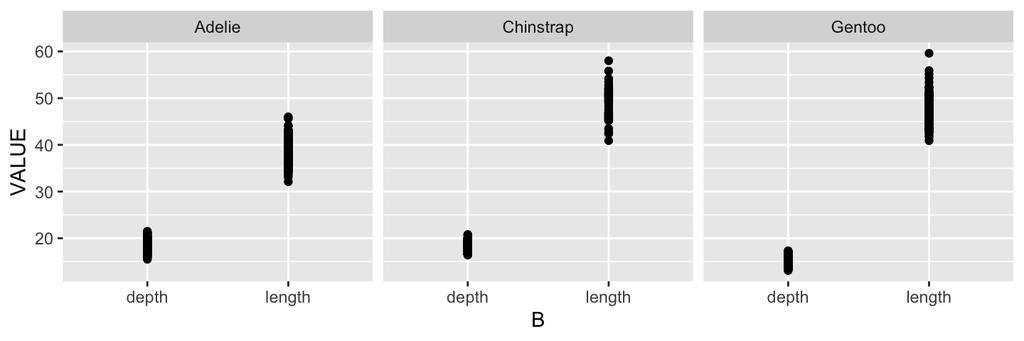

```r
gp = ggplot(data = penguins2_sep) +
  geom_point(aes(x = B, y = VALUE)) +
  facet_wrap(~species)
gp
```

## tidyrを使ってみよう！

### 文法（１０）複数の文字列カラムを結合

- **unite(col = 【新しい列名】, 【結合したい列名をベクターで】, sep = 【セパレータ】)**
  - 詳しい使い方は[こちら](https://heavywatal.github.io/rstats/tidyr.html)を参照

```r
penguins2_unite = penguins2_sep %>%
  unite(col = "PARTS", c(A, B, C), sep = ".")
head(penguins2_unite)
```

```
## # A tibble: 6 × 8
##   species island    flipper_length_mm body_mass_g sex     year PARTS       VALUE
##   <fct>   <fct>                 <int>       <int> <fct>  <int> <chr>       <dbl>
## 1 Adelie  Torgersen               181        3750 male    2007 bill.lengt…  39.1
## 2 Adelie  Torgersen               181        3750 male    2007 bill.depth…  18.7
## 3 Adelie  Torgersen               186        3800 female  2007 bill.lengt…  39.5
## 4 Adelie  Torgersen               186        3800 female  2007 bill.depth…  17.4
## 5 Adelie  Torgersen               195        3250 female  2007 bill.lengt…  40.3
## 6 Adelie  Torgersen               195        3250 female  2007 bill.depth…  18
```

## tidyrの文法まとめ

- 文法（８−１）**pivod_wider()** …縦長を横広に
- 文法（８−２）**pivod_longer()**…横広を縦長に
- 文法（９）**separate()**…カラムを分割
- 文法（１０）**unite()**…カラムを結合
- 他にもたくさん便利な機能がある
- 知りたかったらこのあたり
  - [R自学自習の基礎知識（Heavy Watal）](https://heavywatal.github.io/rstats/dplyr.html)

## dplyrとtidyrのまとめ

### **データを解析したいな**

- まずはどんなグラフを描きたいか考えよう
- 次にどんなdata.frameがほしいか考えよう

### **どうやるんだっけ**

- 規則性のある形ならだいたいなんとかなる。
- 具体的な方法を忘れたらググる！前のコードを使い回す！
- めっちゃエラーが出るんですけど…
  - 凡ミスがないか確認、エラーコードもよく読む
  - 経験者に相談
  - よくあるエラー集

### **→Step 4：自分のデータを扱おう**